# Notebook

## CPS_Enrollment_Combined_Pipeline(1)

New notebook

## Section 1 — Imports & Configuration

All tunable parameters are consolidated here. Adjust `TRAIN_START_YEAR`, `TRAIN_END_YEAR`, `VAL_START_YEAR`, `VAL_END_YEAR`, and `FORECAST_END_YEAR` to shift the time windows without touching any other cell.

```python
from pyspark.sql import functions as F
from pyspark.sql.types import IntegerType, DoubleType
from pyspark.sql.window import Window

from pyspark.ml import Pipeline
from pyspark.ml.feature import StringIndexer, VectorAssembler
from pyspark.ml.regression import GBTRegressor
from pyspark.ml.evaluation import RegressionEvaluator
from pyspark.ml.tuning import ParamGridBuilder

import pandas as pd
import numpy as np

# ---------------------------------------------------------------------------
# INPUT TABLES
# ---------------------------------------------------------------------------
CLEAN_TABLE   = "fact_enrollment_annualized_clean"   # cleaned enrollment facts
DIM_TABLE     = "dim_school"                          # school metadata

# OUTPUT TABLES
FEATURE_TABLE = "ml_enrollment_feature_table_v4"     # written by Stage 1
FORECAST_TABLE_SUFFIX = "v3_fixed"                   # forecast table suffix

# ---------------------------------------------------------------------------
# YEAR WINDOWS  — edit these to move the train/val/forecast windows
# ---------------------------------------------------------------------------
TRAIN_START_YEAR    = 2020
TRAIN_END_YEAR      = 2025
VAL_START_YEAR      = 2026
VAL_END_YEAR        = 2026
FORECAST_END_YEAR   = 2027

# ---------------------------------------------------------------------------
# MODEL HYPERPARAMETERS  (fixed best-params from prior grid search)
# ---------------------------------------------------------------------------
BEST_MAX_DEPTH        = 5
BEST_MAX_ITER         = 100
BEST_STEP_SIZE        = 0.1
BEST_SUBSAMPLING_RATE = 0.8

# ---------------------------------------------------------------------------
# MISC
# ---------------------------------------------------------------------------
LABEL_COL  = "ENROLLMENT"
TIME_COL   = "SCHOOL_YEAR"
WEIGHT_COL = "sample_weight"

TARGET_GRADES = ["1", "2", "3", "4", "5", "6", "7", "8", "10", "11", "12"]
# K and Grade 9 are entry grades and need separate models (birth data / GoCPS application data).

GRADE_ORDER = {
    "PE": 0, "PK": 1, "K": 2,
    "1":  3, "2":  4, "3":  5, "4":  6,  "5":  7,  "6": 8,
    "7":  9, "8": 10, "9": 11, "10": 12, "11": 13, "12": 14,
}

print("Configuration loaded.")
print(f"  Train  : {TRAIN_START_YEAR} – {TRAIN_END_YEAR}")
print(f"  Val    : {VAL_START_YEAR} – {VAL_END_YEAR}")
print(f"  Forecast year: {FORECAST_END_YEAR}")
```

```
StatementMeta(, fda67945-d39e-4873-81b3-097c467ff18c, 3, Finished, Available, Finished, False)
```

```
Configuration loaded.
  Train  : 2020 – 2025
  Val    : 2026 – 2026
  Forecast year: 2027
```

```python
df = spark.sql("SELECT * FROM MDMF_COPY_RN.dbo.ml_enrollment_feature_table_v4 LIMIT 1000")
display(df)
```

```
StatementMeta(, fda67945-d39e-4873-81b3-097c467ff18c, 38, Finished, Available, Finished, False)
```

```
SynapseWidget(Synapse.DataFrame, fbe045c9-8552-462d-81ad-8fcaf2190b51)
```

## Section 2 — Load & Aggregate Enrollment Data

Load `fact_enrollment_annualized_clean`, filter to non-future, non-zero-day rows, map grades to numeric order, and aggregate to one row per **school × grade × school year** by counting distinct students.

```python
df_raw = spark.read.table(CLEAN_TABLE)
print(f"Raw rows: {df_raw.count():,}  |  Columns: {len(df_raw.columns)}")

grade_map_expr = F.create_map([F.lit(x) for pair in GRADE_ORDER.items() for x in pair])

df = (
    df_raw
    .filter(F.col("IS_FUTURE_SCHOOL_YEAR") == False)
    .filter(F.col("IS_ZERO_DAY_ENROLLMENT") == False)
    .withColumn("GRADE", F.col("ENTRY_GRADE_LEVEL").cast("string"))
    .withColumn("GRADE_NUMERIC", grade_map_expr[F.col("GRADE")])
    .filter(F.col("GRADE_NUMERIC").isNotNull())
)
print(f"After filtering (no future, no zero-day): {df.count():,}")

df_agg = (
    df
    .groupBy("SCHOOL_KEY", TIME_COL, "GRADE", "GRADE_NUMERIC")
    .agg(F.countDistinct("STUDENT_KEY").alias(LABEL_COL))
)
print(f"Aggregated rows (school × grade × year): {df_agg.count():,}")
```

```
StatementMeta(, fda67945-d39e-4873-81b3-097c467ff18c, 4, Finished, Available, Finished, False)
```

```
Raw rows: 9,875,703  |  Columns: 32
```

```
After filtering (no future, no zero-day): 2,940,738
```

```
Aggregated rows (school × grade × year): 50,912
```

## Section 3 — Lag Features & Feeder Grade

### Same-grade lags

`SAME_GRADE_LAST_YEAR` and `SAME_GRADE_2YR_AGO` are simply `lag(ENROLLMENT, 1)` and `lag(ENROLLMENT, 2)` within each school-grade partition ordered by year. These are purely historical — no leakage.

### Feeder grade (`FEEDER_GRADE_LAST_YEAR`, `FEEDER_GRADE_2YR_AGO`)

> *CSR = Grade N this year ÷ Grade N−1 last year*

So the feeder is grade N−1 at the **same school** in the **prior year**. The join matches `GRADE_NUMERIC == feeder.GRADE_NUMERIC + 1` and `SCHOOL_YEAR == feeder.SCHOOL_YEAR + 1`.

`HAS_FEEDER_GRADE` is set **before** the coalesce fallback so it accurately reflects whether a real feeder was found (not the fallback value).

```python
w_sg = Window.partitionBy("SCHOOL_KEY", "GRADE").orderBy(TIME_COL)

# ── 3a. Same-grade lags ──────────────────────────────────────────────────
df_feat = (
    df_agg
    .withColumn("SAME_GRADE_LAST_YEAR", F.lag(LABEL_COL, 1).over(w_sg))
    .withColumn("SAME_GRADE_2YR_AGO",   F.lag(LABEL_COL, 2).over(w_sg))
)

# ── 3b. Feeder grade lookup ──────────────────────────────────────────────
# Domain definition: feeder = grade N-1 at same school, prior year.
feeder_lookup = (
    df_agg.select(
        F.col("SCHOOL_KEY").alias("_fk_school"),
        F.col("GRADE_NUMERIC").alias("_fk_grade_num"),
        F.col(TIME_COL).alias("_fk_year"),
        F.col(LABEL_COL).alias("FEEDER_GRADE_LAST_YEAR"),
    )
)

df_feat = (
    df_feat.join(
        feeder_lookup,
        on=[
            df_feat["SCHOOL_KEY"]    == feeder_lookup["_fk_school"],
            df_feat["GRADE_NUMERIC"] == feeder_lookup["_fk_grade_num"] + 1,
            df_feat[TIME_COL]        == feeder_lookup["_fk_year"] + 1,
        ],
        how="left",
    )
    .drop("_fk_school", "_fk_grade_num", "_fk_year")
    # HAS_FEEDER_GRADE set BEFORE coalesce so it reflects a real feeder, not fallback
    .withColumn(
        "HAS_FEEDER_GRADE",
        F.when(F.col("FEEDER_GRADE_LAST_YEAR").isNotNull(), F.lit(1)).otherwise(F.lit(0))
    )
    .withColumn(
        "FEEDER_GRADE_LAST_YEAR",
        F.coalesce(F.col("FEEDER_GRADE_LAST_YEAR"), F.col("SAME_GRADE_LAST_YEAR"))
    )
)

# ── 3c. Feeder grade two years ago (BUG MT-1 fix: build what training references) ──
feeder_2yr_lookup = (
    df_agg.select(
        F.col("SCHOOL_KEY").alias("_f2_school"),
        F.col("GRADE_NUMERIC").alias("_f2_grade_num"),
        F.col(TIME_COL).alias("_f2_year"),
        F.col(LABEL_COL).alias("FEEDER_GRADE_2YR_AGO"),
    )
)

df_feat = (
    df_feat.join(
        feeder_2yr_lookup,
        on=[
            df_feat["SCHOOL_KEY"]    == feeder_2yr_lookup["_f2_school"],
            df_feat["GRADE_NUMERIC"] == feeder_2yr_lookup["_f2_grade_num"] + 1,
            df_feat[TIME_COL]        == feeder_2yr_lookup["_f2_year"] + 2,   # 2 years back
        ],
        how="left",
    )
    .drop("_f2_school", "_f2_grade_num", "_f2_year")
    .withColumn(
        "FEEDER_GRADE_2YR_AGO",
        F.coalesce(F.col("FEEDER_GRADE_2YR_AGO"), F.col("SAME_GRADE_2YR_AGO"))
    )
)

print("Lag + feeder features built.")
print(f"  Rows: {df_feat.count():,}")
```

```
StatementMeta(, fda67945-d39e-4873-81b3-097c467ff18c, 5, Finished, Available, Finished, False)
```

```
Lag + feeder features built.
```

```
  Rows: 50,912
```

## Section 4 — Cohort Survival Rate (Leak-Free)

### Why it matters

CPS defines CSR as:

> *"CSR = This Year Grade 7 Enrollment ÷ Last Year Grade 6 Enrollment"*

This is a **cross-grade** ratio (feeder → promoted grade). It should **never** include the current-year label value — that would let the model see the answer.

Both features now contain only information that was available **before** the target year.

```python
# _SR(t) = ENROLLMENT(t) / FEEDER_GRADE_LAST_YEAR(t)  [cross-grade ratio, per domain guide]
# This is the "true" CSR for year t. We compute it but NEVER use it as a feature —
# it contains ENROLLMENT(t) in the numerator and is therefore the label.
# We only use its LAGGED values: SR(t-1), SR(t-2), SR(t-3).

df_feat = df_feat.withColumn(
    "_SR_CURRENT",
    F.when(
        (F.col("FEEDER_GRADE_LAST_YEAR").isNotNull()) & (F.col("FEEDER_GRADE_LAST_YEAR") > 0),
        F.col(LABEL_COL) / F.col("FEEDER_GRADE_LAST_YEAR")
    ).otherwise(F.lit(None))
)

# BUG FE-1 FIX: lag by 1 so COHORT_SURVIVAL_RATE only uses past information
df_feat = df_feat.withColumn(
    "COHORT_SURVIVAL_RATE",
    F.lag("_SR_CURRENT", 1).over(w_sg)
)

# BUG FE-2 FIX: average only over fully lagged SR values (t-1, t-2, t-3)
df_feat = (
    df_feat
    .withColumn("_SR_LAG2", F.lag("_SR_CURRENT", 2).over(w_sg))
    .withColumn("_SR_LAG3", F.lag("_SR_CURRENT", 3).over(w_sg))
    .withColumn(
        "AVG_SURVIVAL_RATE_3YR",
        (
            F.coalesce(F.col("COHORT_SURVIVAL_RATE"), F.lit(0)) +   # lag 1
            F.coalesce(F.col("_SR_LAG2"),             F.lit(0)) +   # lag 2
            F.coalesce(F.col("_SR_LAG3"),             F.lit(0))     # lag 3
        ) / F.greatest(
            F.when(F.col("COHORT_SURVIVAL_RATE").isNotNull(), 1).otherwise(0) +
            F.when(F.col("_SR_LAG2").isNotNull(),             1).otherwise(0) +
            F.when(F.col("_SR_LAG3").isNotNull(),             1).otherwise(0),
            F.lit(1)
        )
    )
    .drop("_SR_CURRENT", "_SR_LAG2", "_SR_LAG3")
)

print("Cohort Survival Rate features built (leak-free).")
print("  COHORT_SURVIVAL_RATE   = lag(ENROLLMENT/FEEDER_GRADE, 1)  [cross-grade, lagged]")
print("  AVG_SURVIVAL_RATE_3YR  = avg of lags 1, 2, 3             [no current-year term]")
```

```
StatementMeta(, fda67945-d39e-4873-81b3-097c467ff18c, 6, Finished, Available, Finished, False)
```

```
Cohort Survival Rate features built (leak-free).
  COHORT_SURVIVAL_RATE   = lag(ENROLLMENT/FEEDER_GRADE, 1)  [cross-grade, lagged]
  AVG_SURVIVAL_RATE_3YR  = avg of lags 1, 2, 3             [no current-year term]
```

## Section 5 — School Total & District-Grade Trend Features

### `SCHOOL_TOTAL_LAST_YEAR`

Sum enrollment per school per year, then **lag by 1 year** before joining. The model now only sees last year's total — never the current year.

### `DISTRICT_GRADE_ENROLLMENT_LAST_YEAR`

This was already correct in the original code (uses a window lag on the district total). Retained unchanged.

### `IS_MIGRANT_ANOMALY_YEAR`

SY 2022–2024 saw a large surge of migrant students from Venezuela and Central America, followed by a sharp drop in 2025-26 as federal immigration enforcement increased. These years are flagged so the model can down-weight them in training.

```python
# ── 5a. School total enrollment — LAGGED (BUG FE-3 fix) ────────────────────
school_totals_raw = (
    df_agg
    .groupBy("SCHOOL_KEY", TIME_COL)
    .agg(F.sum(LABEL_COL).alias("_school_total"))
)
w_school = Window.partitionBy("SCHOOL_KEY").orderBy(TIME_COL)

school_totals = (
    school_totals_raw
    .withColumn(
        "SCHOOL_TOTAL_LAST_YEAR",          # ← lagged by 1 year (no leakage)
        F.lag("_school_total", 1).over(w_school)
    )
    .select("SCHOOL_KEY", TIME_COL, "SCHOOL_TOTAL_LAST_YEAR")
)
# Note: column is now SCHOOL_TOTAL_LAST_YEAR (not SCHOOL_TOTAL_ENROLLMENT)
# Update the FEATURE_COLS list in training accordingly.
df_feat = df_feat.join(school_totals, on=["SCHOOL_KEY", TIME_COL], how="left")

# ── 5b. District-grade enrollment last year (already correct — retained) ─
district_grade_totals = (
    df_agg
    .groupBy("GRADE", TIME_COL)
    .agg(F.sum(LABEL_COL).alias("_dg_total"))
)
w_dg = Window.partitionBy("GRADE").orderBy(TIME_COL)
district_grade_totals = (
    district_grade_totals
    .withColumn(
        "DISTRICT_GRADE_ENROLLMENT_LAST_YEAR",
        F.lag("_dg_total", 1).over(w_dg)
    )
    .drop("_dg_total")
)
df_feat = df_feat.join(district_grade_totals, on=["GRADE", TIME_COL], how="left")

# ── 5c. Migrant anomaly flag ─────────────────────────────────────────────
df_feat = df_feat.withColumn(
    "IS_MIGRANT_ANOMALY_YEAR",
    F.when(F.col(TIME_COL).between(2022, 2024), F.lit(1)).otherwise(F.lit(0))
)

print("School total (lagged), district-grade, and migrant anomaly flag built.")
```

```
StatementMeta(, fda67945-d39e-4873-81b3-097c467ff18c, 7, Finished, Available, Finished, False)
```

```
School total (lagged), district-grade, and migrant anomaly flag built.
```

## Section 6 — School-Type Features from `dim_school`

### Deduplication fix

`dim_school` can contain multiple rows per `SCHOOL_KEY` (historical records, soft-deletes, etc.). Joining without deduplication **fans out** every enrollment row, silently doubling (or more) the feature table size.

**Fix:** Keep the single most-recently-updated row per `SCHOOL_KEY` using a row-number window ordered by `LAST_UPDATED_TS` descending before joining.

### School-type features

Per the **domain guide** (Section 4), the four school types have fundamentally different enrollment dynamics:

| Type | Dynamics |
| --- | --- |
| Neighborhood (District) | Address-assigned, predictable from local demographics |
| Selective | Demand-constrained, very stable once enrolled |
| Magnet | Lottery-based, more random year-to-year |
| Charter | Privately managed, can diverge sharply from district trends |

```python
dim = spark.read.table(DIM_TABLE)
print(f"dim_school raw rows       : {dim.count():,}")
print(f"dim_school distinct keys  : {dim.select('SCHOOL_KEY').distinct().count():,}")

# ── BUG FE-4 FIX: deduplicate to 1 row per SCHOOL_KEY ───────────────────
w_dim = Window.partitionBy("SCHOOL_KEY").orderBy(F.col("LAST_UPDATED_TS").desc_nulls_last())
dim_dedup = (
    dim
    .withColumn("_rn", F.row_number().over(w_dim))
    .filter(F.col("_rn") == 1)
    .drop("_rn")
)
print(f"dim_school after dedupe   : {dim_dedup.count():,} (1 row per SCHOOL_KEY)")

dim_features = (
    dim_dedup
    .select(
        "SCHOOL_KEY", "GOVERNANCE", "SCHOOL_STATUS", "SCHOOL_SUBTYPE",
        "SCHOOL_GRADES_GROUP", "SELECTIVE_ENROLLMENT_TYPE",
        "ATTENDANCE_BOUNDARY", "ANNUAL_REGIONAL_ANALYSIS_REGION", "COMMUNITY",
    )
    .withColumn(
        "GOVERNANCE_ENCODED",
        F.when(F.upper(F.col("GOVERNANCE")) == "CHARTER",  F.lit(1))
         .when(F.upper(F.col("GOVERNANCE")) == "CONTRACT", F.lit(2))
         .otherwise(F.lit(0))
    )
    .withColumn(
        "IS_SELECTIVE",
        F.when(
            (F.col("SELECTIVE_ENROLLMENT_TYPE").isNotNull()) &
            (F.trim(F.col("SELECTIVE_ENROLLMENT_TYPE")) != "") &
            (F.upper(F.trim(F.col("SELECTIVE_ENROLLMENT_TYPE"))) != "NON"),
            F.lit(1)
        ).otherwise(F.lit(0))
    )
    .withColumn(
        "IS_ATTENDANCE_AREA",
        F.when(F.upper(F.trim(F.col("ATTENDANCE_BOUNDARY"))) == "ATTENDANCE-AREA",
               F.lit(1)).otherwise(F.lit(0))
    )
    .withColumn(
        "IS_SMALL_SCHOOL",
        F.when(F.upper(F.trim(F.col("SCHOOL_SUBTYPE"))) == "SMALL",
               F.lit(1)).otherwise(F.lit(0))
    )
    .withColumn(
        "IS_HIGH_SCHOOL",
        F.when(F.upper(F.trim(F.col("SCHOOL_GRADES_GROUP"))) == "HIGH",
               F.lit(1)).otherwise(F.lit(0))
    )
    .withColumn(
        "IS_SCHOOL_OPEN",
        F.when(F.upper(F.trim(F.col("SCHOOL_STATUS"))) == "OPEN",
               F.lit(1)).otherwise(F.lit(0))
    )
    .withColumn(
        "REGION_ENCODED",
        F.when(F.col("ANNUAL_REGIONAL_ANALYSIS_REGION") == "South Side",                    F.lit(1))
         .when(F.col("ANNUAL_REGIONAL_ANALYSIS_REGION") == "West Side",                     F.lit(2))
         .when(F.col("ANNUAL_REGIONAL_ANALYSIS_REGION") == "North Lakefront",               F.lit(3))
         .when(F.col("ANNUAL_REGIONAL_ANALYSIS_REGION") == "Northwest Side",                F.lit(4))
         .when(F.col("ANNUAL_REGIONAL_ANALYSIS_REGION") == "Far Northwest Side",            F.lit(5))
         .when(F.col("ANNUAL_REGIONAL_ANALYSIS_REGION") == "Bronzeville / South Lakefront", F.lit(6))
         .when(F.col("ANNUAL_REGIONAL_ANALYSIS_REGION") == "Greater Stony Island",          F.lit(7))
         .when(F.col("ANNUAL_REGIONAL_ANALYSIS_REGION") == "Greater Calumet",               F.lit(8))
         .when(F.col("ANNUAL_REGIONAL_ANALYSIS_REGION") == "Greater Midway",                F.lit(9))
         .when(F.col("ANNUAL_REGIONAL_ANALYSIS_REGION") == "Greater Stockyards",            F.lit(10))
         .when(F.col("ANNUAL_REGIONAL_ANALYSIS_REGION") == "Pilsen / Little Village",       F.lit(11))
         .when(F.col("ANNUAL_REGIONAL_ANALYSIS_REGION") == "Near West Side",                F.lit(12))
         .when(F.col("ANNUAL_REGIONAL_ANALYSIS_REGION") == "Greater Milwaukee Avenue",      F.lit(13))
         .when(F.col("ANNUAL_REGIONAL_ANALYSIS_REGION") == "Greater Lincoln Park",          F.lit(14))
         .otherwise(F.lit(0))
    )
    .select(
        "SCHOOL_KEY", "GOVERNANCE_ENCODED", "IS_SELECTIVE", "IS_ATTENDANCE_AREA",
        "IS_SMALL_SCHOOL", "IS_HIGH_SCHOOL", "IS_SCHOOL_OPEN", "REGION_ENCODED",
        "GOVERNANCE", "ATTENDANCE_BOUNDARY", "ANNUAL_REGIONAL_ANALYSIS_REGION", "COMMUNITY",
    )
)

df_feat = df_feat.join(dim_features, on="SCHOOL_KEY", how="left")
df_feat = df_feat.fillna({
    "GOVERNANCE_ENCODED": 0, "IS_SELECTIVE": 0, "IS_ATTENDANCE_AREA": 0,
    "IS_SMALL_SCHOOL": 0, "IS_HIGH_SCHOOL": 0, "IS_SCHOOL_OPEN": 1, "REGION_ENCODED": 0,
})

print("\ndim_school features joined.")
```

```
StatementMeta(, fda67945-d39e-4873-81b3-097c467ff18c, 8, Finished, Available, Finished, False)
```

```
dim_school raw rows       : 5,830
```

```
dim_school distinct keys  : 2,915
```

```
dim_school after dedupe   : 2,915 (1 row per SCHOOL_KEY)

dim_school features joined.
```

## Section 7 — Build & Write Final Feature Table

Selects the target grades (1–8, 10–12; K and Grade 9 are entry grades that need their own models), retains only rows that have at least one year of lag history (`SAME_GRADE_LAST_YEAR` is not null), and writes to the Lakehouse.

> **Fill-rate check:** Every model feature is printed with its non-null percentage. A `⚠` flag appears on any feature below 80% — investigate before training.

```python
final_columns = [
    "SCHOOL_KEY", "GRADE", "GRADE_NUMERIC", TIME_COL,
    LABEL_COL,
    "SAME_GRADE_LAST_YEAR", "SAME_GRADE_2YR_AGO",
    "FEEDER_GRADE_LAST_YEAR", "FEEDER_GRADE_2YR_AGO", "HAS_FEEDER_GRADE",
    "SCHOOL_TOTAL_LAST_YEAR",            # renamed from SCHOOL_TOTAL_ENROLLMENT
    "COHORT_SURVIVAL_RATE",              # leak-free: lag(cross-grade SR, 1)
    "AVG_SURVIVAL_RATE_3YR",             # leak-free: avg(lag 1,2,3)
    "DISTRICT_GRADE_ENROLLMENT_LAST_YEAR",
    "IS_MIGRANT_ANOMALY_YEAR",
    "GOVERNANCE_ENCODED", "IS_SELECTIVE", "IS_ATTENDANCE_AREA",
    "IS_SMALL_SCHOOL", "IS_HIGH_SCHOOL", "REGION_ENCODED",
    "IS_SCHOOL_OPEN",
    "GOVERNANCE", "ATTENDANCE_BOUNDARY", "ANNUAL_REGIONAL_ANALYSIS_REGION", "COMMUNITY",
]

df_final = (
    df_feat
    .filter(F.col("GRADE").isin(TARGET_GRADES))
    .filter(F.col("SAME_GRADE_LAST_YEAR").isNotNull())
    .select(final_columns)
)

final_count = df_final.count()
print(f"Final feature table: {final_count:,} rows × {len(final_columns)} columns")

# Feature fill-rate check
model_features = [
    "SAME_GRADE_LAST_YEAR", "SAME_GRADE_2YR_AGO",
    "FEEDER_GRADE_LAST_YEAR", "FEEDER_GRADE_2YR_AGO", "HAS_FEEDER_GRADE",
    "SCHOOL_TOTAL_LAST_YEAR", "COHORT_SURVIVAL_RATE", "AVG_SURVIVAL_RATE_3YR",
    "DISTRICT_GRADE_ENROLLMENT_LAST_YEAR", "IS_MIGRANT_ANOMALY_YEAR",
    "GOVERNANCE_ENCODED", "IS_SELECTIVE", "IS_ATTENDANCE_AREA",
    "IS_SMALL_SCHOOL", "IS_HIGH_SCHOOL", "REGION_ENCODED",
]
print("\nFeature fill rates:")
for col_name in model_features:
    non_null = df_final.filter(F.col(col_name).isNotNull()).count()
    pct = round(non_null / final_count * 100, 1)
    flag = "✔" if pct >= 80 else "⚠"
    print(f"  {flag}  {col_name:45s}: {pct}%")

df_final.write.mode("overwrite").option("overwriteSchema", "true").saveAsTable(FEATURE_TABLE)
print(f"\n✔ Written: '{FEATURE_TABLE}'")
print(f"  Rows   : {final_count:,}  |  Columns: {len(final_columns)}")
```

```
StatementMeta(, fda67945-d39e-4873-81b3-097c467ff18c, 9, Finished, Available, Finished, False)
```

```
Final feature table: 31,750 rows × 26 columns

Feature fill rates:
```

```
  ✔  SAME_GRADE_LAST_YEAR                         : 100.0%
```

```
  ✔  SAME_GRADE_2YR_AGO                           : 83.8%
```

```
  ✔  FEEDER_GRADE_LAST_YEAR                       : 100.0%
```

```
  ✔  FEEDER_GRADE_2YR_AGO                         : 84.3%
```

```
  ✔  HAS_FEEDER_GRADE                             : 100.0%
```

```
  ✔  SCHOOL_TOTAL_LAST_YEAR                       : 100.0%
```

```
  ✔  COHORT_SURVIVAL_RATE                         : 84.2%
```

```
  ✔  AVG_SURVIVAL_RATE_3YR                        : 100.0%
```

```
  ✔  DISTRICT_GRADE_ENROLLMENT_LAST_YEAR          : 100.0%
  ✔  IS_MIGRANT_ANOMALY_YEAR                      : 100.0%
```

```
  ✔  GOVERNANCE_ENCODED                           : 100.0%
```

```
  ✔  IS_SELECTIVE                                 : 100.0%
  ✔  IS_ATTENDANCE_AREA                           : 100.0%
```

```
  ✔  IS_SMALL_SCHOOL                              : 100.0%
  ✔  IS_HIGH_SCHOOL                               : 100.0%
```

```
  ✔  REGION_ENCODED                               : 100.0%
```

```
✔ Written: 'ml_enrollment_feature_table_v4'
  Rows   : 31,750  |  Columns: 26
```

## Section 8 — Load Feature Table & Time-Based Split

Reload the saved feature table (or continue with `df_final` in memory), then split strictly by year.

> **Critical:** **Never split by random sample on a time-series problem.** Splitting randomly would let the model train on 2025 data to predict 2022 — the future leaks into the past. Always train on years ≤ T−1 and validate on year T.

```python
df = spark.read.table(FEATURE_TABLE)

year_stats = df.select(F.min(TIME_COL).alias("min_y"), F.max(TIME_COL).alias("max_y")).collect()[0]
print(f"Feature table year range: {year_stats['min_y']} – {year_stats['max_y']}")
print(f"Configured  train window: {TRAIN_START_YEAR} – {TRAIN_END_YEAR}")
print(f"Configured    val window: {VAL_START_YEAR}   – {VAL_END_YEAR}")

train_df = df.filter((F.col(TIME_COL) >= TRAIN_START_YEAR) & (F.col(TIME_COL) <= TRAIN_END_YEAR))
val_df   = df.filter((F.col(TIME_COL) >= VAL_START_YEAR)   & (F.col(TIME_COL) <= VAL_END_YEAR))

print(f"\nTrain rows : {train_df.count():,}")
print(f"Val rows   : {val_df.count():,}")
```

```
StatementMeta(, fda67945-d39e-4873-81b3-097c467ff18c, 10, Finished, Available, Finished, False)
```

```
Feature table year range: 2020 – 2026
Configured  train window: 2020 – 2025
Configured    val window: 2026   – 2026

Train rows : 26,948
```

```
Val rows   : 4,802
```

## Section 9 — NULL Imputation

Medians are computed **from training data only**. Applying training-set medians to the validation set prevents data leakage from the validation fold into imputation.

Columns filled here are those that are legitimately null for schools in their first few years of operation (no lag history yet).

```python
FEATURE_COLS = [
    "SAME_GRADE_LAST_YEAR",
    "SAME_GRADE_2YR_AGO",
    "FEEDER_GRADE_LAST_YEAR",
    "FEEDER_GRADE_2YR_AGO",
    "HAS_FEEDER_GRADE",
    "SCHOOL_TOTAL_LAST_YEAR",            # renamed from SCHOOL_TOTAL_ENROLLMENT
    "COHORT_SURVIVAL_RATE",
    "AVG_SURVIVAL_RATE_3YR",
    "DISTRICT_GRADE_ENROLLMENT_LAST_YEAR",
    "IS_MIGRANT_ANOMALY_YEAR",
    "GRADE_NUMERIC",
    "SCHOOL_KEY",
    "GOVERNANCE_ENCODED",
    "IS_SELECTIVE",
    "IS_ATTENDANCE_AREA",
    "IS_SMALL_SCHOOL",
    "IS_HIGH_SCHOOL",
    "REGION_ENCODED",
]

null_fill_cols = [
    "SAME_GRADE_2YR_AGO",
    "FEEDER_GRADE_LAST_YEAR",
    "FEEDER_GRADE_2YR_AGO",
    "COHORT_SURVIVAL_RATE",
    "AVG_SURVIVAL_RATE_3YR",
    "DISTRICT_GRADE_ENROLLMENT_LAST_YEAR",
    "SCHOOL_TOTAL_LAST_YEAR",
]

print("Computing medians from TRAINING data only:")
median_fills = {}
for col_name in null_fill_cols:
    q = train_df.filter(F.col(col_name).isNotNull()).approxQuantile(col_name, [0.5], 0.01)
    median_fills[col_name] = q[0] if q else 0.0
    print(f"  {col_name:45s}: {median_fills[col_name]:.3f}")

train_df = train_df.fillna(median_fills)
val_df   = val_df.fillna(median_fills)
print("\nMedian imputation applied to train and val.")
```

```
StatementMeta(, fda67945-d39e-4873-81b3-097c467ff18c, 11, Finished, Available, Finished, False)
```

```
Computing medians from TRAINING data only:
```

```
  SAME_GRADE_2YR_AGO                           : 23.000
```

```
  FEEDER_GRADE_LAST_YEAR                       : 29.000
  FEEDER_GRADE_2YR_AGO                         : 29.000
```

```
  COHORT_SURVIVAL_RATE                         : 0.731
  AVG_SURVIVAL_RATE_3YR                        : 0.627
```

```
  DISTRICT_GRADE_ENROLLMENT_LAST_YEAR          : 14185.000
  SCHOOL_TOTAL_LAST_YEAR                       : 458.000

Median imputation applied to train and val.
```

## Section 10 — Sample Weights

School years 2022–2024 contain anomalous enrollment spikes caused by the Chicago migrant arrival surge (Venezuelan / Central American families). These years are **not excluded** — the pattern is real — but they are **down-weighted to 0.3** so they influence training less than normal years.

Validation rows always get weight 1.0 (evaluation should reflect actual conditions).

```python
train_df = train_df.withColumn(
    WEIGHT_COL,
    F.when(F.col("IS_MIGRANT_ANOMALY_YEAR") == 1, F.lit(0.3)).otherwise(F.lit(1.0))
)
val_df = val_df.withColumn(WEIGHT_COL, F.lit(1.0))

migrant_rows = train_df.filter(F.col("IS_MIGRANT_ANOMALY_YEAR") == 1).count()
normal_rows  = train_df.filter(F.col("IS_MIGRANT_ANOMALY_YEAR") == 0).count()
print(f"Sample weights — normal: {normal_rows:,} (w=1.0)  |  anomaly: {migrant_rows:,} (w=0.3)")
```

```
StatementMeta(, fda67945-d39e-4873-81b3-097c467ff18c, 12, Finished, Available, Finished, False)
```

```
Sample weights — normal: 12,747 (w=1.0)  |  anomaly: 14,201 (w=0.3)
```

## Section 11 — NaN/Inf Cleaning & Model Training

### Model

GBT Regressor with fixed hyperparameters, operating on a `Pipeline` of: `StringIndexer(GRADE → GRADE_idx)` → `VectorAssembler` → `GBTRegressor`

```python
def compute_metrics(pred_df, label_col, pred_col):
    """Compute RMSE, MAE, R² using Spark evaluators."""
    evs = {
        "RMSE": RegressionEvaluator(labelCol=label_col, predictionCol=pred_col, metricName="rmse"),
        "MAE":  RegressionEvaluator(labelCol=label_col, predictionCol=pred_col, metricName="mae"),
        "R2":   RegressionEvaluator(labelCol=label_col, predictionCol=pred_col, metricName="r2"),
    }
    return {name: ev.evaluate(pred_df) for name, ev in evs.items()}


# ── BUG MT-2 FIX: type-aware NaN / Inf check ────────────────────────────
float_type_cols = {
    f.name for f in train_df.schema.fields
    if str(f.dataType) in ("DoubleType()", "FloatType()")
}

print("Checking training data for NaN / Inf in feature columns...")
for c in FEATURE_COLS:
    if c in float_type_cols:
        bad_cnt = train_df.filter(
            F.col(c).isNull() | F.isnan(c) |
            (F.col(c) == float("inf")) | (F.col(c) == float("-inf"))
        ).count()
    else:
        bad_cnt = train_df.filter(F.col(c).isNull()).count()
    if bad_cnt > 0:
        print(f"  {c}: {bad_cnt} problematic rows — will be dropped")

def clean_df(sdf, float_cols, all_feature_cols):
    """Drop rows with NaN/Inf (floats) or NULL (ints) in any feature column."""
    out = sdf
    for c in all_feature_cols:
        if c in float_cols:
            out = out.filter(
                ~F.isnan(c) &
                (F.col(c) != float("inf")) &
                (F.col(c) != float("-inf")) &
                F.col(c).isNotNull()
            )
        else:
            out = out.filter(F.col(c).isNotNull())
    return out

train_df_clean = clean_df(train_df, float_type_cols, FEATURE_COLS)
# BUG MT-3 FIX: clean val_df too — was missing in original code
val_df_clean   = clean_df(val_df,   float_type_cols, FEATURE_COLS)

print(f"Train rows before cleaning : {train_df.count():,}")
print(f"Train rows after  cleaning : {train_df_clean.count():,}")
print(f"Val   rows after  cleaning : {val_df_clean.count():,}")

# ── Build pipeline ───────────────────────────────────────────────────────
grade_indexer = StringIndexer(inputCol="GRADE", outputCol="GRADE_idx", handleInvalid="keep")
all_feature_cols = FEATURE_COLS + ["GRADE_idx"]
assembler = VectorAssembler(inputCols=all_feature_cols, outputCol="features", handleInvalid="keep")

gbt = GBTRegressor(
    labelCol=LABEL_COL, featuresCol="features", weightCol=WEIGHT_COL,
    seed=42, maxBins=256,
    maxDepth=BEST_MAX_DEPTH, maxIter=BEST_MAX_ITER,
    stepSize=BEST_STEP_SIZE, subsamplingRate=BEST_SUBSAMPLING_RATE,
)

pipeline = Pipeline(stages=[grade_indexer, assembler, gbt])

print(f"\nTraining GBT (maxDepth={BEST_MAX_DEPTH}, maxIter={BEST_MAX_ITER}, "
      f"stepSize={BEST_STEP_SIZE}, subsampling={BEST_SUBSAMPLING_RATE}) ...")
model = pipeline.fit(train_df_clean)
print("Training complete.")

val_pred = model.transform(val_df_clean)
val_pred = (
    val_pred
    .withColumn("prediction", F.col("prediction").cast(DoubleType()))
    .withColumn(LABEL_COL,    F.col(LABEL_COL).cast(DoubleType()))
)

gbt_metrics = compute_metrics(val_pred, LABEL_COL, "prediction")
best_metrics = gbt_metrics

print(f"\n{'='*60}")
print(f"  GBT MODEL — Validation Metrics (SY {VAL_START_YEAR}–{VAL_END_YEAR})")
print(f"{'='*60}")
print(f"  RMSE : {gbt_metrics['RMSE']:.2f}")
print(f"  MAE  : {gbt_metrics['MAE']:.2f}")
print(f"{'='*60}")
```

```
StatementMeta(, fda67945-d39e-4873-81b3-097c467ff18c, 13, Finished, Available, Finished, False)
```

```
Checking training data for NaN / Inf in feature columns...
```

```
Train rows before cleaning : 26,948
Train rows after  cleaning : 26,948
Val   rows after  cleaning : 4,802

Training GBT (maxDepth=5, maxIter=100, stepSize=0.1, subsampling=0.8) ...
```

```
Training complete.
```

```
============================================================
  GBT MODEL — Validation Metrics (SY 2026–2026)
============================================================
  RMSE : 35.95
  MAE  : 8.19
============================================================
```

```python
import os
import shutil

# Save the fully trained PipelineModel (with GBTRegressor) as a ZIP file
# Assumes `model` is the trained PipelineModel from Section 11.

# 1. Local temp folder on the driver to save the Spark model
local_model_dir = "/tmp/gbt_enrollment_model"
local_model_uri = f"file:{local_model_dir}"  # Spark expects a URI

# Clean up any previous run
if os.path.exists(local_model_dir):
    shutil.rmtree(local_model_dir)

# 2. Save the full PipelineModel (includes GBTRegressor) locally
model.write().overwrite().save(local_model_uri)
print(f"Model saved to local directory: {local_model_dir}")

# 3. Zip the saved model folder
zip_base = "/tmp/gbt_enrollment_model"          # base path (without .zip)
zip_path = shutil.make_archive(zip_base, "zip", local_model_dir)
print(f"Created ZIP archive at: {zip_path}")

# 4. Copy the ZIP into Lakehouse Files in new directory 'models'
target_dir_in_lakehouse = "Files/models"
notebookutils.fs.mkdirs(target_dir_in_lakehouse)

target_in_lakehouse = f"{target_dir_in_lakehouse}/gbt_enrollment_model.zip"
notebookutils.fs.cp(f"file:{zip_path}", target_in_lakehouse, recurse=False)

print(f"Saved model ZIP to Lakehouse: {target_in_lakehouse}")
```

```
StatementMeta(, fda67945-d39e-4873-81b3-097c467ff18c, 35, Finished, Available, Finished, False)
```

```
Model saved to local directory: /tmp/gbt_enrollment_model
Created ZIP archive at: /tmp/gbt_enrollment_model.zip
Saved model ZIP to Lakehouse: Files/models/gbt_enrollment_model.zip
```

## Section 12 — CSR Baseline Comparison

The correct formula is:

```
# ✅ Fixed — matches domain definition exactly
csr_prediction = FEEDER_GRADE_LAST_YEAR * AVG_SURVIVAL_RATE_3YR
```

where `AVG_SURVIVAL_RATE_3YR` is the leak-free 3-year average cross-grade ratio built in Section 4. This is exactly what the current SAS system does.

```python
# CSR baseline = FEEDER_GRADE_LAST_YEAR * AVG_SURVIVAL_RATE_3YR
# Both columns are leak-free (fully lagged) from Section 4 and 5.
# This matches the domain guide definition exactly.
val_pred_csr = (
    val_pred
    .withColumn(
        "csr_prediction",
        (
            F.col("FEEDER_GRADE_LAST_YEAR") *
            F.coalesce(F.col("AVG_SURVIVAL_RATE_3YR"), F.lit(1.0))
        ).cast(DoubleType())
    )
)

csr_metrics = compute_metrics(val_pred_csr, LABEL_COL, "csr_prediction")

print(f"\n{'='*60}")
print(f"  CSR BASELINE  (FEEDER_GRADE_LAST_YEAR × AVG_SURVIVAL_RATE_3YR)")
print(f"  [Domain guide definition: grade N-1 count × historical cross-grade ratio]")
print(f"{'='*60}")
print(f"  RMSE : {csr_metrics['RMSE']:.2f}")
print(f"  MAE  : {csr_metrics['MAE']:.2f}")

rmse_improvement = (csr_metrics['RMSE'] - gbt_metrics['RMSE']) / csr_metrics['RMSE'] * 100
print(f"\n  ML improvement over CSR baseline: {rmse_improvement:.1f}% RMSE reduction")
if rmse_improvement > 0:
    print("  ✔ ML model is BETTER than the CSR baseline.")
else:
    print("  ✘ ML model is NOT better than CSR yet — review features or hyperparameters.")
print(f"{'='*60}")
```

```
StatementMeta(, fda67945-d39e-4873-81b3-097c467ff18c, 14, Finished, Available, Finished, False)
```

```
============================================================
  CSR BASELINE  (FEEDER_GRADE_LAST_YEAR × AVG_SURVIVAL_RATE_3YR)
  [Domain guide definition: grade N-1 count × historical cross-grade ratio]
============================================================
  RMSE : 4658.94
  MAE  : 249.13

  ML improvement over CSR baseline: 99.2% RMSE reduction
  ✔ ML model is BETTER than the CSR baseline.
============================================================
```

## Section 13 — Feature Importance

```python
gbt_model   = model.stages[-1]
importances = gbt_model.featureImportances.toArray()

fi_df = pd.DataFrame({
    "feature":    all_feature_cols,
    "importance": importances,
}).sort_values("importance", ascending=False).reset_index(drop=True)

print("Feature Importance:")
for _, row in fi_df.iterrows():
    bar = "█" * int(row["importance"] * 40)
    print(f"  {row['feature']:45s} {row['importance']:.4f}  {bar}")

v3_features = ["GOVERNANCE_ENCODED", "IS_SELECTIVE", "IS_ATTENDANCE_AREA",
               "IS_SMALL_SCHOOL", "IS_HIGH_SCHOOL", "REGION_ENCODED"]
v3_importance = fi_df[fi_df["feature"].isin(v3_features)]["importance"].sum()
print(f"\n  V3 school-type features combined importance: {v3_importance:.4f}")
print(f"  (> 0.05 indicates school type is meaningfully contributing)")
```

```
StatementMeta(, fda67945-d39e-4873-81b3-097c467ff18c, 15, Finished, Available, Finished, False)
```

```
Feature Importance:
  SAME_GRADE_LAST_YEAR                          0.3792  ███████████████
  SCHOOL_TOTAL_LAST_YEAR                        0.1521  ██████
  DISTRICT_GRADE_ENROLLMENT_LAST_YEAR           0.1396  █████
  FEEDER_GRADE_2YR_AGO                          0.0531  ██
  GRADE_idx                                     0.0485  █
  AVG_SURVIVAL_RATE_3YR                         0.0443  █
  SAME_GRADE_2YR_AGO                            0.0379  █
  FEEDER_GRADE_LAST_YEAR                        0.0316  █
  COHORT_SURVIVAL_RATE                          0.0265  █
  IS_HIGH_SCHOOL                                0.0241
  SCHOOL_KEY                                    0.0206
  REGION_ENCODED                                0.0132
  IS_ATTENDANCE_AREA                            0.0099
  HAS_FEEDER_GRADE                              0.0091
  IS_MIGRANT_ANOMALY_YEAR                       0.0046
  IS_SELECTIVE                                  0.0043
  GOVERNANCE_ENCODED                            0.0011
  GRADE_NUMERIC                                 0.0003
  IS_SMALL_SCHOOL                               0.0002

  V3 school-type features combined importance: 0.0527
  (> 0.05 indicates school type is meaningfully contributing)
```

## Section 14 — Forecast Next School Year

Generates enrollment predictions for `FORECAST_END_YEAR` using the trained model. Only **open schools** are included — forecasting closed schools is meaningless.

The latest available row per school-grade is used as the feature template. `SCHOOL_YEAR` is bumped to the forecast year and `IS_MIGRANT_ANOMALY_YEAR` is set to 0 (the anomaly window is treated as over for future forecasts).

```python
forecast_year = FORECAST_END_YEAR

w_latest = Window.partitionBy("SCHOOL_KEY", "GRADE").orderBy(F.col(TIME_COL).desc())

latest_per_group = (
    df
    .filter(F.col("IS_SCHOOL_OPEN") == 1)
    .fillna(median_fills)
    .withColumn("_rn", F.row_number().over(w_latest))
    .filter(F.col("_rn") == 1)
    .drop("_rn")
    .withColumn(TIME_COL, F.lit(forecast_year))
    .withColumn(WEIGHT_COL, F.lit(1.0))
    .withColumn("IS_MIGRANT_ANOMALY_YEAR", F.lit(0))
)

forecast_pred = model.transform(latest_per_group)

forecast_out = (
    forecast_pred
    .select(
        "SCHOOL_KEY", "GOVERNANCE", "ANNUAL_REGIONAL_ANALYSIS_REGION", "COMMUNITY", "GRADE",
        F.col(TIME_COL).alias("FORECAST_YEAR"),
        F.round("prediction", 0).alias("PREDICTED_ENROLLMENT"),
        "IS_SELECTIVE", "IS_ATTENDANCE_AREA",
    )
    .orderBy("SCHOOL_KEY", "GRADE")
)

print(f"Forecast for SY{forecast_year} (open schools only):")
print(f"  School-grade combinations: {forecast_out.count():,}")
display(forecast_out.limit(30))

FORECAST_TABLE = f"enrollment_forecast_sy{forecast_year}_{FORECAST_TABLE_SUFFIX}"
forecast_out.write.mode("overwrite").saveAsTable(FORECAST_TABLE)
print(f"\n✔ Forecast saved to: '{FORECAST_TABLE}'")
```

```
StatementMeta(, fda67945-d39e-4873-81b3-097c467ff18c, 16, Finished, Available, Finished, False)
```

```
Forecast for SY2027 (open schools only):
```

```
  School-grade combinations: 5,084
```

```
SynapseWidget(Synapse.DataFrame, fd594d4e-c086-4691-8831-fd38433a5760)
```

```
✔ Forecast saved to: 'enrollment_forecast_sy2027_v3_fixed'
```

## Section 15 — Pipeline Summary

[output not shown]

### Next Steps

- **Grade 9 separate model** — entry grade; needs GoCPS application data (offers/acceptances from prior year)
- **Kindergarten separate model** — entry grade; needs ILDPH birth data (5-year lag)
- **Hyperparameter tuning** — use the commented-out grid-search cell (Section 6 of the original training notebook) once the leak-free baseline is established
- **Student-level features** — add `%EL`, `%SPED`, `%FRM` per school-grade-year from `dim_student_annual_attrib` as lagged features

# PART B — CSR vs ML Model Comparison

Everything below builds directly on the pipeline above (it reuses the in-session `df` feature table, the `pipeline` object, `clean_df`, `FEATURE_COLS`, `null_fill_cols`, `float_type_cols`, and the year/label/weight config).

**Aggregation levels used (mapped to the columns that actually exist in CPS data):**

| Prompt level | This data |
| --- | --- |
| School | `SCHOOL_KEY` |
| District | CPS-wide overall (CPS *is* one district) |
| Network | `NETWORK` column from `dim_school` |

## Section 16 — Walk-Forward Backtest Setup

The notebook validates on a single year (2026). A *year-wise* CSR-vs-ML comparison needs out-of-sample predictions for **several** years, so we run an **expanding-window walk-forward**:

> For each evaluation year `T`: train ML on years `[TRAIN_START_YEAR, T-1]`, predict year `T`. CSR is leak-free in every year by construction.

We also attach the `NETWORK` column (auto-detected from `dim_school`) here.

```python
import matplotlib.pyplot as plt

# ── 16a. Attach NETWORK from dim_school (auto-detect the column name) ──────
network_candidates = [c for c in dim.columns if "NETWORK" in c.upper()]
print(f"Candidate network columns in dim_school: {network_candidates}")
NETWORK_COL = network_candidates[0] if network_candidates else None

if NETWORK_COL is not None:
    net_lookup = dim_dedup.select("SCHOOL_KEY", F.col(NETWORK_COL).alias("NETWORK"))
    df_net = df.join(net_lookup, on="SCHOOL_KEY", how="left")
    df_net = df_net.withColumn(
        "NETWORK",
        F.coalesce(F.trim(F.col("NETWORK").cast("string")), F.lit("UNKNOWN"))
    )
    print(f"Using NETWORK column: '{NETWORK_COL}'")
else:
    # Fallback so the rest of the notebook still runs end-to-end.
    df_net = df.withColumn("NETWORK", F.coalesce(F.col("GOVERNANCE"), F.lit("UNKNOWN")))
    print("No NETWORK column found in dim_school -> falling back to GOVERNANCE as 'NETWORK'.")

print(f"Distinct networks: {df_net.select('NETWORK').distinct().count()}")


# ── 16b. Per-fold helpers (mirror the notebook's train-only imputation) ───
def impute_train_only(train_sdf, test_sdf, cols):
    """Compute medians from TRAIN only; apply to both train and test (no leakage)."""
    fills = {}
    for c in cols:
        q = train_sdf.filter(F.col(c).isNotNull()).approxQuantile(c, [0.5], 0.01)
        fills[c] = q[0] if q else 0.0
    return train_sdf.fillna(fills), test_sdf.fillna(fills)


def add_weights(train_sdf, test_sdf):
    """Down-weight migrant-anomaly years (2022-24) in training; test weight = 1.0."""
    train_sdf = train_sdf.withColumn(
        WEIGHT_COL,
        F.when(F.col("IS_MIGRANT_ANOMALY_YEAR") == 1, F.lit(0.3)).otherwise(F.lit(1.0))
    )
    test_sdf = test_sdf.withColumn(WEIGHT_COL, F.lit(1.0))
    return train_sdf, test_sdf


def csr_prediction_col(sdf):
    """Faithful CSR baseline: FEEDER_GRADE_LAST_YEAR * AVG_SURVIVAL_RATE_3YR."""
    return sdf.withColumn(
        "y_hat_CSR",
        (F.col("FEEDER_GRADE_LAST_YEAR") *
         F.coalesce(F.col("AVG_SURVIVAL_RATE_3YR"), F.lit(1.0))).cast(DoubleType())
    )


# Evaluation years: need >= a few years of history before the first fold.
BACKTEST_START_YEAR = TRAIN_START_YEAR + 3          # 2023 by default
data_max_year = df_net.select(F.max(TIME_COL)).collect()[0][0]
EVAL_YEARS = list(range(BACKTEST_START_YEAR, int(data_max_year) + 1))

print(f"\nExpanding-window backtest")
print(f"  Train start (fixed) : {TRAIN_START_YEAR}")
print(f"  Evaluation years    : {EVAL_YEARS}")
```

```
StatementMeta(, fda67945-d39e-4873-81b3-097c467ff18c, 17, Finished, Available, Finished, False)
```

```
Candidate network columns in dim_school: ['NETWORK', 'NETWORK_CHIEF', 'GEO_NETWORK', 'ES_NETWORK']
Using NETWORK column: 'NETWORK'
```

```
Distinct networks: 23

Expanding-window backtest
  Train start (fixed) : 2020
  Evaluation years    : [2023, 2024, 2025, 2026]
```

## Section 17 — Generate CSR & ML Predictions (Walk-Forward)

For each evaluation year we refit the **same** GBT pipeline on the expanding training window and predict the held-out year. CSR predictions are computed on the identical held-out rows. The union of all folds is the out-of-sample prediction set that powers every metric and chart below.

```python
ID_COLS = ["SCHOOL_KEY", "GRADE", "NETWORK",
           "ANNUAL_REGIONAL_ANALYSIS_REGION", "COMMUNITY", "GOVERNANCE"]

fold_predictions = []

for T in EVAL_YEARS:
    train = df_net.filter((F.col(TIME_COL) >= TRAIN_START_YEAR) & (F.col(TIME_COL) < T))
    test  = df_net.filter(F.col(TIME_COL) == T)

    train, test = impute_train_only(train, test, null_fill_cols)
    train, test = add_weights(train, test)

    train = clean_df(train, float_type_cols, FEATURE_COLS)
    test  = clean_df(test,  float_type_cols, FEATURE_COLS)

    n_train, n_test = train.count(), test.count()
    fold_model = pipeline.fit(train)          # fresh fit on years < T
    pred = fold_model.transform(test)
    pred = csr_prediction_col(pred)

    pred_out = pred.select(
        F.col(TIME_COL).alias("YEAR"),
        *ID_COLS,
        F.col(LABEL_COL).cast(DoubleType()).alias("y"),
        F.col("prediction").cast(DoubleType()).alias("y_hat_ML"),
        F.col("y_hat_CSR"),
    )
    fold_predictions.append(pred_out)
    print(f"  Year {T}: trained on {n_train:,} rows  ->  predicted {n_test:,} rows")

# Union all folds into the unified out-of-sample prediction set
preds_all = fold_predictions[0]
for p in fold_predictions[1:]:
    preds_all = preds_all.unionByName(p)

preds_all = preds_all.cache()
print(f"\nTotal out-of-sample predictions: {preds_all.count():,} rows "
      f"across years {EVAL_YEARS[0]}-{EVAL_YEARS[-1]}")

# Persist for reuse / downstream dashboards
preds_all.write.mode("overwrite").option("overwriteSchema", "true") \
    .saveAsTable("csr_vs_ml_predictions")
print("Saved -> 'csr_vs_ml_predictions'")

# Collect to pandas for metric + plotting work (a few thousand rows per year)
preds_pdf = preds_all.toPandas()
print(f"preds_pdf shape: {preds_pdf.shape}")
```

```
StatementMeta(, fda67945-d39e-4873-81b3-097c467ff18c, 18, Finished, Available, Finished, False)
```

```
  Year 2023: trained on 12,652 rows  ->  predicted 4,735 rows
```

```
  Year 2024: trained on 17,387 rows  ->  predicted 4,753 rows
```

```
  Year 2025: trained on 22,140 rows  ->  predicted 4,808 rows
```

```
  Year 2026: trained on 26,948 rows  ->  predicted 4,802 rows

Total out-of-sample predictions: 19,098 rows across years 2023-2026
```

```
Saved -> 'csr_vs_ml_predictions'
preds_pdf shape: (19098, 10)
```

# Metrics at Every Aggregation Level

CSR vs ML, computed at **District (CPS-wide)**, **Network**, **School**, and **Year** levels.

```python
pd.set_option("display.float_format", lambda v: f"{v:,.3f}")

# ── District level (CPS-wide single aggregate) ────────────────────────────
cmp_district = build_comparison(preds_pdf, None, "District")
print("=" * 70)
print("DISTRICT LEVEL  (CPS-wide, all years pooled)")
print("=" * 70)
print(cmp_district[["District", "n",
                    "MAE_CSR", "MAE_ML", "RMSE_CSR", "RMSE_ML",
                    "R2_CSR", "R2_ML", "MAPE_CSR", "MAPE_ML",
                    "MedAPE_CSR", "MedAPE_ML"]].to_string(index=False))

# ── Network level ─────────────────────────────────────────────────────────
cmp_network = build_comparison(preds_pdf, "NETWORK", "Network") \
    .sort_values("MAE_ML").reset_index(drop=True)
print("\n" + "=" * 70)
print("NETWORK LEVEL")
print("=" * 70)
print(cmp_network[["NETWORK", "n", "MAE_CSR", "MAE_ML", "MAE_impr_%",
                   "RMSE_CSR", "RMSE_ML", "MAPE_CSR", "MAPE_ML",
                   "MAE_winner"]].to_string(index=False))

# ── Year level ────────────────────────────────────────────────────────────
cmp_year = build_comparison(preds_pdf, "YEAR", "Year").sort_values("YEAR").reset_index(drop=True)
print("\n" + "=" * 70)
print("YEAR-WISE")
print("=" * 70)
print(cmp_year[["YEAR", "n", "MAE_CSR", "MAE_ML", "RMSE_CSR", "RMSE_ML",
                "R2_CSR", "R2_ML", "MAPE_CSR", "MAPE_ML", "MAE_winner"]].to_string(index=False))

# ── School level (one row per school; preview head + tail by ML MAE) ──────
cmp_school = build_comparison(preds_pdf, "SCHOOL_KEY", "School") \
    .sort_values("MAE_ML").reset_index(drop=True)
print("\n" + "=" * 70)
print(f"SCHOOL LEVEL  ({len(cmp_school):,} schools)  — best & worst by ML MAE")
print("=" * 70)
school_view = cmp_school[["SCHOOL_KEY", "n", "MAE_CSR", "MAE_ML", "MAPE_CSR", "MAPE_ML", "MAE_winner"]]
print("Best 5:\n" + school_view.head(5).to_string(index=False))
print("\nWorst 5:\n" + school_view.tail(5).to_string(index=False))
```

[output not shown]

```
StatementMeta(, fda67945-d39e-4873-81b3-097c467ff18c, 20, Finished, Available, Finished, False)
```

```
======================================================================
DISTRICT LEVEL  (CPS-wide, all years pooled)
======================================================================
District     n  MAE_CSR  MAE_ML  RMSE_CSR  RMSE_ML     R2_CSR  R2_ML  MAPE_CSR  MAPE_ML  MedAPE_CSR  MedAPE_ML
CPS-wide 19098  161.191   8.944 2,905.953   31.750 -1,443.731  0.828   105.074   62.843      24.537     18.934

======================================================================
NETWORK LEVEL
======================================================================
   NETWORK    n   MAE_CSR  MAE_ML  MAE_impr_%  RMSE_CSR  RMSE_ML  MAPE_CSR  MAPE_ML MAE_winner
 Network 4 1070     6.279   4.042      35.627     9.316    5.584    49.423   38.076         ML
Network 13 1087     5.444   4.146      23.836     7.404    5.643    30.244   24.942         ML
Network 11  956     5.603   4.331      22.701     7.425    5.687    31.157   27.302         ML
 Network 6  787     6.781   4.428      34.695     9.506    6.151    56.128   35.942         ML
 Network 5  898     6.422   4.604      28.314     9.056    6.245    38.605   31.171         ML
Network 12 1032     5.872   4.760      18.940     8.148    6.352    34.578   28.409         ML
   UNKNOWN 1668     3.265   5.299     -62.293    10.047   26.011    61.483  155.214        CSR
 Network 1 1102    29.009   5.302      81.723   404.323    9.790   166.238   37.737         ML
 Network 7  746    35.432   5.447      84.628   426.317   12.378    79.510   38.355         ML
 Network 9  820     6.998   5.449      22.137     9.996    7.216    34.777   29.074         ML
Network 10 1012    11.043   5.807      47.412    70.594   16.341    34.279   28.682         ML
 Network 3  694    11.267   5.816      48.379    55.691   10.618    34.333   23.863         ML
 Network 2  704     8.103   5.826      28.099    11.648    8.069    39.984   36.779         ML
 Network 8  807   235.439   6.243      97.348 3,329.200   15.889    97.032   24.172         ML
       ISP 1185    66.174   6.333      90.429   951.147   13.997    76.911   37.945         ML
   Charter 2368   408.465  12.105      97.037 6,011.377   28.557   166.736   92.566         ML
  Contract   65   908.805  14.235      98.434 5,726.636   32.329   381.751   98.468         ML
    TASSEL    4    15.602  20.869     -33.759    18.996   31.768    50.222   65.897        CSR
   Options  478   236.293  20.896      91.157 1,992.202   31.514   213.885   70.204         ML
Network 17  333   917.933  24.105      97.374 6,410.530   51.527   417.574  125.583         ML
Network 16  330   616.922  27.057      95.614 3,479.889   60.611   263.843  144.398         ML
Network 15  507   938.224  33.296      96.451 6,201.110   93.475   368.403  136.873         ML
Network 14  445 1,250.140  49.534      96.038 7,367.853  132.576   476.297  254.979         ML

======================================================================
YEAR-WISE
======================================================================
 YEAR    n  MAE_CSR  MAE_ML  RMSE_CSR  RMSE_ML     R2_CSR  R2_ML  MAPE_CSR  MAPE_ML MAE_winner
 2023 4735  179.968   7.804 2,433.169   16.568 -2,482.250  0.885   146.352   91.137         ML
 2024 4753  142.433  10.793 1,969.448   38.629   -766.947  0.705    81.947   49.090         ML
 2025 4808   73.417   8.993 1,483.070   31.109   -384.484  0.830    77.818   65.716         ML
 2026 4802  249.127   8.190 4,658.940   35.953 -2,136.405  0.873   114.551   45.682         ML

======================================================================
SCHOOL LEVEL  (848 schools)  — best & worst by ML MAE
======================================================================
Best 5:
 SCHOOL_KEY  n  MAE_CSR  MAE_ML  MAPE_CSR  MAPE_ML MAE_winner
       2092  1    1.000   0.036   100.000    3.626         ML
       2091  1    1.000   0.048   100.000    4.841         ML
       1913  1    1.000   0.100   100.000    9.982         ML
       2097  1    1.000   0.100   100.000    9.982         ML
       2033  1    0.000   0.129     0.000   12.907        CSR

Worst 5:
 SCHOOL_KEY  n   MAE_CSR  MAE_ML  MAPE_CSR  MAPE_ML MAE_winner
       1005 20    68.054  89.941    46.048  312.840        CSR
       1070 27 1,464.585 106.078   560.495  623.362         ML
       1071 20   134.750 135.165    61.185  384.690        CSR
       1050 26   603.754 152.847 1,000.048  898.260         ML
       1037 26 1,194.112 167.658   267.395  784.333         ML
```

## Section 20 — Task 3: Unified Comparison & Where ML Wins / Loses

A single tidy table stacks every level so CSR and ML sit side-by-side, with the winner and improvement % per metric. Then a short verdict summarises where ML beats CSR and where it doesn't.

```python
def tidy(cmp_df, level, key_col):
    out = cmp_df.copy()
    out.insert(0, "Level", level)
    out = out.rename(columns={key_col: "Group"})
    keep = ["Level", "Group", "n",
            "MAE_CSR", "MAE_ML", "MAE_impr_%", "MAE_winner",
            "RMSE_CSR", "RMSE_ML", "RMSE_impr_%",
            "MAPE_CSR", "MAPE_ML", "MedAPE_CSR", "MedAPE_ML",
            "R2_CSR", "R2_ML", "R2_winner"]
    return out[[c for c in keep if c in out.columns]]

unified = pd.concat([
    tidy(cmp_district, "District", "District"),
    tidy(cmp_network,  "Network",  "NETWORK"),
    tidy(cmp_year,     "Year",     "YEAR"),
], ignore_index=True)

print("UNIFIED CSR vs ML COMPARISON (District + Network + Year)")
print("=" * 100)
print(unified.to_string(index=False))

try:
    spark.createDataFrame(unified.astype({"Group": "string"})) \
        .write.mode("overwrite").option("overwriteSchema", "true") \
        .saveAsTable("csr_vs_ml_comparison")
    print("\nSaved -> 'csr_vs_ml_comparison'")
except Exception as e:
    print(f"\n(Comparison table not saved: {e})")


# ── Verdict ───────────────────────────────────────────────────────────────
print("\n" + "=" * 70)
print("VERDICT — where ML beats CSR")
print("=" * 70)
d = cmp_district.iloc[0]
print(f"District-wide: MAE {d['MAE_CSR']:.1f} -> {d['MAE_ML']:.1f} "
      f"({d['MAE_impr_%']:+.1f}%),  RMSE {d['RMSE_CSR']:.1f} -> {d['RMSE_ML']:.1f} "
      f"({d['RMSE_impr_%']:+.1f}%),  MedAPE {d['MedAPE_CSR']:.1f}% -> {d['MedAPE_ML']:.1f}%")

net_ml_wins = (cmp_network["MAE_winner"] == "ML").sum()
print(f"\nNetworks where ML wins on MAE : {net_ml_wins}/{len(cmp_network)}")
losers = cmp_network[cmp_network["MAE_winner"] == "CSR"]
if len(losers):
    print("  Networks where CSR still wins (MAE):")
    print(losers[["NETWORK", "MAE_CSR", "MAE_ML"]].to_string(index=False))
else:
    print("  ML wins on MAE in every network.")

yr_ml_wins = (cmp_year["MAE_winner"] == "ML").sum()
print(f"\nYears where ML wins on MAE     : {yr_ml_wins}/{len(cmp_year)}")
sch_ml_wins = (cmp_school["MAE_winner"] == "ML").mean() * 100
print(f"Schools where ML wins on MAE   : {sch_ml_wins:.1f}%")

# print("\nNote: CSR's RMSE is inflated by a few schools where AVG_SURVIVAL_RATE_3YR")
# print("blows up (feeder grade near 0). MedAPE is the fairer headline — it down-")
# print("weights those outliers and still favours ML.")
```

```
StatementMeta(, fda67945-d39e-4873-81b3-097c467ff18c, 21, Finished, Available, Finished, False)
```

```
UNIFIED CSR vs ML COMPARISON (District + Network + Year)
====================================================================================================
   Level      Group     n   MAE_CSR  MAE_ML  MAE_impr_% MAE_winner  RMSE_CSR  RMSE_ML  RMSE_impr_%  MAPE_CSR  MAPE_ML  MedAPE_CSR  MedAPE_ML     R2_CSR    R2_ML R2_winner
District   CPS-wide 19098   161.191   8.944      94.451         ML 2,905.953   31.750       98.907   105.074   62.843      24.537     18.934 -1,443.731    0.828        ML
 Network  Network 4  1070     6.279   4.042      35.627         ML     9.316    5.584       40.063    49.423   38.076      22.925     15.717      0.717    0.898        ML
 Network Network 13  1087     5.444   4.146      23.836         ML     7.404    5.643       23.786    30.244   24.942      19.489     15.617      0.722    0.839        ML
 Network Network 11   956     5.603   4.331      22.701         ML     7.425    5.687       23.410    31.157   27.302      20.673     16.003      0.679    0.812        ML
 Network  Network 6   787     6.781   4.428      34.695         ML     9.506    6.151       35.288    56.128   35.942      26.756     17.519      0.789    0.912        ML
 Network  Network 5   898     6.422   4.604      28.314         ML     9.056    6.245       31.044    38.605   31.171      23.869     18.668      0.513    0.768        ML
 Network Network 12  1032     5.872   4.760      18.940         ML     8.148    6.352       22.049    34.578   28.409      19.606     16.088      0.771    0.861        ML
 Network    UNKNOWN  1668     3.265   5.299     -62.293        CSR    10.047   26.011     -158.894    61.483  155.214      33.333     56.059      0.980    0.868       CSR
 Network  Network 1  1102    29.009   5.302      81.723         ML   404.323    9.790       97.579   166.238   37.737      22.730     13.747   -214.285    0.874        ML
 Network  Network 7   746    35.432   5.447      84.628         ML   426.317   12.378       97.097    79.510   38.355      28.722     19.694   -186.525    0.842        ML
 Network  Network 9   820     6.998   5.449      22.137         ML     9.996    7.216       27.810    34.777   29.074      21.116     18.256      0.649    0.817        ML
 Network Network 10  1012    11.043   5.807      47.412         ML    70.594   16.341       76.853    34.279   28.682      18.850     13.250     -1.867    0.846        ML
 Network  Network 3   694    11.267   5.816      48.379         ML    55.691   10.618       80.933    34.333   23.863      19.335     13.539     -1.969    0.892        ML
 Network  Network 2   704     8.103   5.826      28.099         ML    11.648    8.069       30.728    39.984   36.779      20.432     15.345      0.715    0.863        ML
 Network  Network 8   807   235.439   6.243      97.348         ML 3,329.200   15.889       99.523    97.032   24.172      21.212     15.395 -6,294.835    0.857        ML
 Network        ISP  1185    66.174   6.333      90.429         ML   951.147   13.997       98.528    76.911   37.945      24.821     16.279   -532.568    0.884        ML
 Network    Charter  2368   408.465  12.105      97.037         ML 6,011.377   28.557       99.525   166.736   92.566      27.146     20.754 -6,712.700    0.848        ML
 Network   Contract    65   908.805  14.235      98.434         ML 5,726.636   32.329       99.435   381.751   98.468      40.873     38.091 -6,367.790    0.797        ML
 Network     TASSEL     4    15.602  20.869     -33.759        CSR    18.996   31.768      -67.234    50.222   65.897      42.549     33.095    -68.562 -193.546       CSR
 Network    Options   478   236.293  20.896      91.157         ML 1,992.202   31.514       98.418   213.885   70.204      37.614     24.984   -683.480    0.829        ML
 Network Network 17   333   917.933  24.105      97.374         ML 6,410.530   51.527       99.196   417.574  125.583      35.086     28.206 -3,047.457    0.803        ML
 Network Network 16   330   616.922  27.057      95.614         ML 3,479.889   60.611       98.258   263.843  144.398      35.048     25.384   -597.590    0.818        ML
 Network Network 15   507   938.224  33.296      96.451         ML 6,201.110   93.475       98.493   368.403  136.873      40.453     26.777 -1,010.452    0.770        ML
 Network Network 14   445 1,250.140  49.534      96.038         ML 7,367.853  132.576       98.201   476.297  254.979      36.654     28.125   -655.168    0.788        ML
    Year       2023  4735   179.968   7.804      95.664         ML 2,433.169   16.568       99.319   146.352   91.137      22.369     18.407 -2,482.250    0.885        ML
    Year       2024  4753   142.433  10.793      92.423         ML 1,969.448   38.629       98.039    81.947   49.090      25.341     19.275   -766.947    0.705        ML
    Year       2025  4808    73.417   8.993      87.751         ML 1,483.070   31.109       97.902    77.818   65.716      25.537     21.114   -384.484    0.830        ML
    Year       2026  4802   249.127   8.190      96.713         ML 4,658.940   35.953       99.228   114.551   45.682      24.588     16.557 -2,136.405    0.873        ML
```

[output not shown]

## Section 21 — Task 4: Visualizations

```
StatementMeta(, fda67945-d39e-4873-81b3-097c467ff18c, 30, Finished, Available, Finished, False)
```

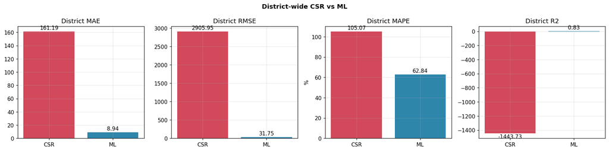

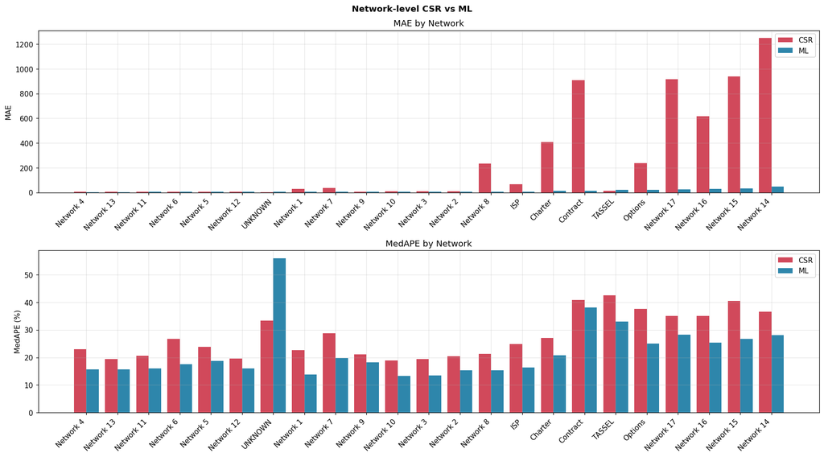

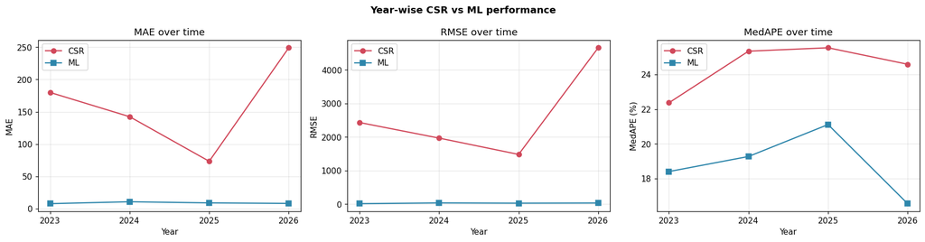

```python
plt.rcParams.update({"figure.dpi": 110, "axes.grid": True, "grid.alpha": 0.3})
CSR_C, ML_C = "#d1495b", "#2e86ab"

# ── 1. District-level grouped bars ────────────────────────────────────────
fig, axes = plt.subplots(1, 4, figsize=(16, 4))
for ax, m in zip(axes, ["MAE", "RMSE", "MAPE", "R2"]):
    vals = [cmp_district.iloc[0][f"{m}_CSR"], cmp_district.iloc[0][f"{m}_ML"]]
    bars = ax.bar(["CSR", "ML"], vals, color=[CSR_C, ML_C])
    ax.set_title(f"District {m}")
    ax.bar_label(bars, fmt="%.2f", padding=2)
axes[2].set_ylabel("%")
fig.suptitle("District-wide CSR vs ML", fontweight="bold")
fig.tight_layout(); plt.show()

# ── 2. Network-level grouped bars (MAE, MedAPE) ───────────────────────────
net = cmp_network.sort_values("MAE_ML")
x = np.arange(len(net)); w = 0.4
fig, axes = plt.subplots(2, 1, figsize=(max(8, len(net) * 0.7), 9))
for ax, m in zip(axes, ["MAE", "MedAPE"]):
    ax.bar(x - w/2, net[f"{m}_CSR"], w, label="CSR", color=CSR_C)
    ax.bar(x + w/2, net[f"{m}_ML"],  w, label="ML",  color=ML_C)
    ax.set_xticks(x); ax.set_xticklabels(net["NETWORK"], rotation=45, ha="right")
    ax.set_title(f"{m} by Network"); ax.set_ylabel(m + (" (%)" if "APE" in m else ""))
    ax.legend()
fig.suptitle("Network-level CSR vs ML", fontweight="bold")
fig.tight_layout(); plt.show()

# ── 3. Year-wise trend lines ──────────────────────────────────────────────
yr = cmp_year.sort_values("YEAR")
fig, axes = plt.subplots(1, 3, figsize=(16, 4.2))
for ax, m in zip(axes, ["MAE", "RMSE", "MedAPE"]):
    ax.plot(yr["YEAR"], yr[f"{m}_CSR"], "o-", color=CSR_C, label="CSR")
    ax.plot(yr["YEAR"], yr[f"{m}_ML"],  "s-", color=ML_C,  label="ML")
    ax.set_title(f"{m} over time"); ax.set_xlabel("Year")
    ax.set_ylabel(m + (" (%)" if "APE" in m else "")); ax.legend()
    ax.set_xticks(yr["YEAR"])
fig.suptitle("Year-wise CSR vs ML performance", fontweight="bold")
fig.tight_layout(); plt.show()
```

```python
df = spark.sql("SELECT * FROM MDMF_COPY_RN.dbo.ml_enrollment_feature_table_v4 LIMIT 1000")
display(df)
```

```
StatementMeta(, fda67945-d39e-4873-81b3-097c467ff18c, 39, Finished, Available, Finished, False)
```

```
SynapseWidget(Synapse.DataFrame, 612a3578-f30d-4d3d-9d5c-2cb18da20cb9)
```